# Project1

Rhay

2/22/2021

```r
#read the file into dataframe

#set working directory

setwd("C:/Users/rp303/OneDrive/Documents/coursera data science/ReproducibleResearchProject1")

#create file

filename <- "repdata_data_activity.zip"

## Check if the file exists already in the directory and if not, download and unzip the files in a folder
##named UCI HAR Dataset

if (!file.exists(filename)){
  fileURL <- "https://d396qusza40orc.cloudfront.net/getdata%2Fprojectfiles%2FUCI%20HAR%20Dataset.zip "
  download.file(fileURL, filename, method="curl")
}
if (!file.exists("repdata_data_activity")) {
  unzip(filename)
}

# load activity excel file into a data table
activitydata = read.csv("activity.csv")
summary(activitydata)
```

```
##      steps            date              interval
##  Min.   :  0.00   Length:17568       Min.   :   0.0
##  1st Qu.:  0.00   Class :character   1st Qu.: 588.8
##  Median :  0.00   Mode  :character   Median :1177.5
##  Mean   : 37.38                      Mean   :1177.5
##  3rd Qu.: 12.00                      3rd Qu.:1766.2
##  Max.   :806.00                      Max.   :2355.0
##  NA's   :2304
```

```r
head(activitydata)
```

```
##   steps       date interval
## 1    NA 2012-10-01        0
## 2    NA 2012-10-01        5
## 3    NA 2012-10-01       10
## 4    NA 2012-10-01       15
## 5    NA 2012-10-01       20
## 6    NA 2012-10-01       25
```

## What is the mean total number of steps taken per day?

#ignore the missing values

```r
#calculate the total number of steps by day
data2sum<-aggregate(x=activitydata$steps, by =list(activitydata$date), FUN=sum)
data2sum
```

```
##       Group.1     x
## 1  2012-10-01    NA
## 2  2012-10-02   126
## 3  2012-10-03 11352
## 4  2012-10-04 12116
## 5  2012-10-05 13294
## 6  2012-10-06 15420
## 7  2012-10-07 11015
## 8  2012-10-08    NA
## 9  2012-10-09 12811
## 10 2012-10-10  9900
## 11 2012-10-11 10304
## 12 2012-10-12 17382
## 13 2012-10-13 12426
## 14 2012-10-14 15098
```

[output cut: 47 more lines]

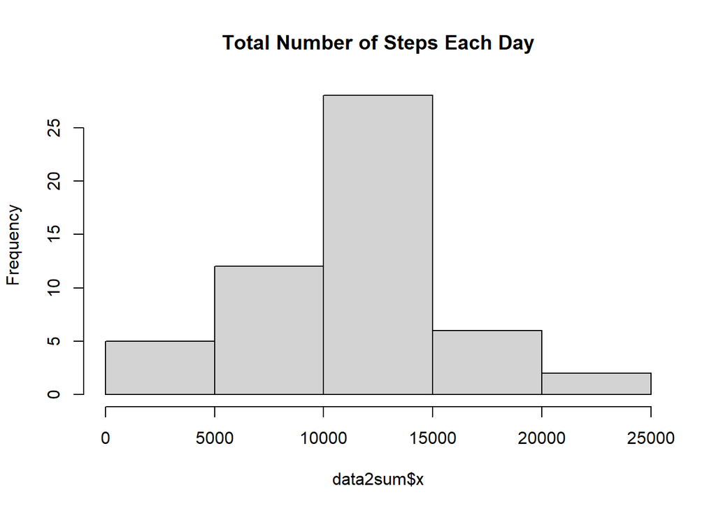

```r
#create a histogram of the steps each day
plot1<-hist(data2sum$x, main="Total Number of Steps Each Day")
```

```r
png(filename="plot1.png")
plot(plot1)
dev.off()
```

```r
#calculate the mean and ignore the NAs
data2summean<-mean(data2sum$x, na.rm = TRUE)
cat("The mean total of the total number of steps = ", data2summean)
```

```
## The mean total of the total number of steps =  10766.19
```

```r
#calculate the median and ignore the NAs
data2summedian<-median(data2sum$x, na.rm = TRUE)
cat("The median total of the total number of steps = ", data2summedian)
```

```
## The median total of the total number of steps =  10765
```

#What is average daily activity pattern? Make a time series plot (i.e. type = “l”) of the 5-minute interval (x-axis) and the average number of steps taken, averaged across all days (y-axis) Which 5-minute interval, on average across all the days in the dataset, contains the maximum number of steps?

```r
#calculate the average steps by interval
#calculate the avarage number of steps by interval

avgactivitydata<-aggregate(steps~interval,data=activitydata, FUN=mean, na.rm=TRUE)

#look at avgactivitydata
head(avgactivitydata)
```

```
##   interval     steps
## 1        0 1.7169811
## 2        5 0.3396226
## 3       10 0.1320755
## 4       15 0.1509434
## 5       20 0.0754717
## 6       25 2.0943396
```

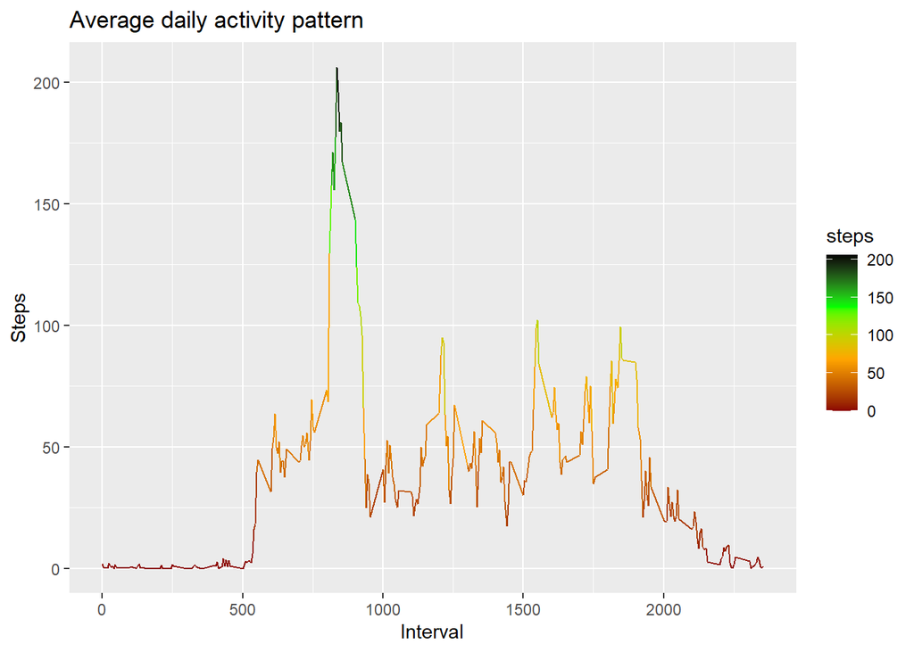

```r
#make a time series plot of interval vs. mean steps
cbPalette <- c("#999999", "#E69F00", "#56B4E9", "#009E73", "#F0E442", "#0072B2", "#D55E00", "#CC79A7")

plot2<-ggplot(avgactivitydata, aes(x = interval, y = steps, color = steps)) +
  geom_line()  + labs(title = "Average daily activity pattern",
       x = "Interval", y = "Steps") +scale_colour_gradientn(colours = c("darkred", "orange", "green", "black"))


plot2
```

```r
ggsave("plot2.png",plot=plot2)
#which 5 min. interval contains max num. steps
maxsteps<-avgactivitydata[which.max(avgactivitydata$steps),]

cat("The maximum average steps were",maxsteps$steps, "and occurred in interval", maxsteps$interval)
```

```
## The maximum average steps were 206.1698 and occurred in interval 835
```

#Imputing missing values Note that there are a number of days/intervals where there are missing values (coded as NA). The presence of missing days may introduce bias into some calculations or summaries of the data.